# Instalación de R y RStudio

Santiago Gualchi

8 de septiembre de 2018

El primer paso antes de escribir la primera línea de código es instalar el software necesario. Para empezar a usar R, necesitamos instalar:

- el intérprete de R (al que también llamamos R); y
- el entorno de desarrollo integrado (IDE) RStudio.

# Instalación de R

1. Dirigirse a https://www.r-project.org/.
2. Hacer clic en [CRAN](https://cran.r-project.org/mirrors.html) en la barra lateral.

[figure not shown]

3. Elegir el mirror [0-Cloud](https://cloud.r-project.org/) (este mirror selecciona automáticamente el mirror más cercano a tu ubicación).

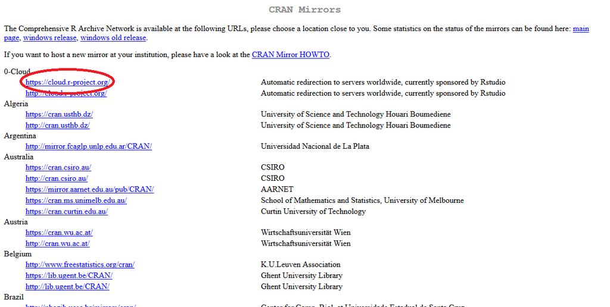

4. Elegir la opción correspondiente a tu sistema operativo: [Linux](https://cloud.r-project.org/bin/linux/), [Mac](https://cloud.r-project.org/bin/macosx/) o [Windows](https://cloud.r-project.org/bin/windows/).

[figure not shown]

## Instrucciones para la instalación en Windows.

1. Hacer clic en [Download R for Windows](https://cloud.r-project.org/bin/windows/).
2. Hacer clic en [base](https://cloud.r-project.org/).

[figure not shown]

3. Hacer clic en Download R x.x.x for Windows y descargar el instalador.
4. Abrir el instalador y aceptar los permisos de administrador.

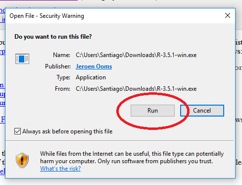

5. Elegir el idioma preferido. Recomiendo instalar R (y, en general, cualquier herramienta de desarrollo) en inglés porque resulta más sencillo encontrar soporte en este idioma (principalmente para resolución de errores de sintaxis).

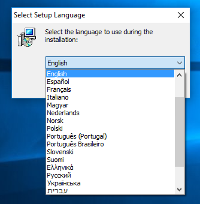

6. Leer y aceptar los términos y condiciones de la GNU GPL.

[figure not shown]

7. Seleccionar la ubicación donde se desea instalar R. Recomiendo mantener la opción por defecto.

[figure not shown]

8. Seleccionar los componentes que se desean instalar. La opción por defecto suele ser la óptima.

[figure not shown]

9. Si bien customizar la instalación de programas suele evitarnos la instalación silenciosa de adware, en este caso el instalador de R quiere saber si queremos personalizar las opciones de arranque. Seleccionar No (accept defaults).

[figure not shown]

10. Seleccionar la carpeta donde deseamos encontrar R en el menú inicio. Recomiendo mantener la opción por defecto.

[figure not shown]

11. Dejar las tareas adicionales con los valores por defecto.

[figure not shown]

12. Esperar a que la instalación termine.

[figure not shown]

13. ¡Listo! R ya está instalado.

[figure not shown]

# Instalación de RStudio

1. Dirigirse a https://www.rstudio.com/.
2. Desplegar el menú bajo Products y hacer clic en RStudio.

[figure not shown]

3. Escrolear hacia abajo y elegir la opción Download RStudio Desktop.

[figure not shown]

## Instrucciones para la instalación en Windows.

4. Escrolear hacia abajo, elegir RStudio x.x.xxx - Windows Vista 7/8/10 y descargar el instalador.

[figure not shown]

5. Abrir el instalador y aceptar los permisos de administrador.

[figure not shown]

6. Seleccionar la ubicación donde se desea instalar RStudio. Recomiendo mantener la opción por defecto.

[figure not shown]

7. Seleccionar la carpeta donde deseamos encontrar RStudio en el menú inicio. Recomiendo mantener la opción por defecto.

[figure not shown]

8. Esperar a que la instalación termine.

[figure not shown]

9. ¡Listo! RStudio ya está instalado.

[figure not shown]

# Ejecutar RStudio

## Instrucciones para Windows

1. Ejecutar desde el menú Inicio.

[figure not shown]

2. ¡Ya está todo listo para empezar a usar R!

[figure not shown]

# Nota

Este trabajo es de distribución gratuita, y se encuentra licenciado bajo [Creative Commons Atribución-NoComercial-SinDerivadas 4.0 Internacional (CC BY-NC-ND 4.0)](https://creativecommons.org/licenses/by-nc-nd/4.0/deed.es).